# Categorical data and permutation tests

Peter Ralph

21 January 2020 – Advanced Biological Statistics

# Hair and eye color

## Hair and Eye color

```r
data(HairEyeColor)
```

```
HairEyeColor             package:datasets              R Documentation

Hair and Eye Color of Statistics Students

Description:

     Distribution of hair and eye color and sex in 592 statistics
     students.

Usage:

     HairEyeColor

Format:

     A 3-dimensional array resulting from cross-tabulating 592
     observations on 3 variables.  The variables and their levels are
     as follows:

       No  Name  Levels
        1  Hair  Black, Brown, Red, Blond
        2  Eye   Brown, Blue, Hazel, Green
        3  Sex   Male, Female

Details:

     The Hair x Eye table comes from a survey of students at the
     University of Delaware reported by Snee (1974).  The split by
     ‘Sex’ was added by Friendly (1992a) for didactic purposes.

     This data set is useful for illustrating various techniques for
     the analysis of contingency tables, such as the standard
     chi-squared test or, more generally, log-linear modelling, and
     graphical methods such as mosaic plots, sieve diagrams or
     association plots.

Source:

     <URL:
     http://euclid.psych.yorku.ca/ftp/sas/vcd/catdata/haireye.sas>

     Snee (1974) gives the two-way table aggregated over ‘Sex’.  The
     ‘Sex’ split of the ‘Brown hair, Brown eye’ cell was changed to
     agree with that used by Friendly (2000).

References:

     Snee, R. D. (1974).  Graphical display of two-way contingency
     tables.  _The American Statistician_, *28*, 9-12.  doi:
     10.2307/2683520 (URL: http://doi.org/10.2307/2683520).
```

```
## , , Sex = Male
##
##        Eye
## Hair    Brown Blue Hazel Green
##   Black    32   11    10     3
##   Brown    53   50    25    15
##   Red      10   10     7     7
##   Blond     3   30     5     8
##
## , , Sex = Female
##
##        Eye
## Hair    Brown Blue Hazel Green
##   Black    36    9     5     2
##   Brown    66   34    29    14
##   Red      16    7     7     7
##   Blond     4   64     5     8
```

```r
haireye <- as.data.frame(HairEyeColor)
names(haireye) <- tolower(names(haireye))
names(haireye)[names(haireye) == "freq"] <- "number"
haireye
```

```
##     hair   eye    sex number
## 1  Black Brown   Male     32
## 2  Brown Brown   Male     53
## 3    Red Brown   Male     10
## 4  Blond Brown   Male      3
## 5  Black  Blue   Male     11
## 6  Brown  Blue   Male     50
## 7    Red  Blue   Male     10
## 8  Blond  Blue   Male     30
## 9  Black Hazel   Male     10
## 10 Brown Hazel   Male     25
## 11   Red Hazel   Male      7
## 12 Blond Hazel   Male      5
## 13 Black Green   Male      3
## 14 Brown Green   Male     15
```

[output cut: 18 more lines]

*Questions:*

1. Are hair and eye color independent in this sample?
2. Do hair and eye color proportions differ by sex?

# Method 2: Permutation

## recall the $p$-value

… is the probability of seeing something at least as extreme as what we saw in the data, if the null hypothesis (model) is true.

A permutation test *estimates* the “probability … under the null hypothesis” part.

- “the null hypothesis” is that *hair and eye color are independent*.
- we can use… the chi-squared statistic for “at least as extreme”?

First, “individualize” the data:

```r
long_haireye <- haireye[rep(1:nrow(haireye), haireye$number),
                        c("hair", "eye", "sex")]
stopifnot(nrow(long_haireye) == sum(haireye$number))
long_haireye
```

```
##        hair   eye    sex
## 1     Black Brown   Male
## 1.1   Black Brown   Male
## 1.2   Black Brown   Male
## 1.3   Black Brown   Male
## 1.4   Black Brown   Male
## 1.5   Black Brown   Male
## 1.6   Black Brown   Male
## 1.7   Black Brown   Male
## 1.8   Black Brown   Male
## 1.9   Black Brown   Male
## 1.10  Black Brown   Male
## 1.11  Black Brown   Male
## 1.12  Black Brown   Male
## 1.13  Black Brown   Male
## 1.14  Black Brown   Male
## 1.15  Black Brown   Male
## 1.16  Black Brown   Male
## 1.17  Black Brown   Male
## 1.18  Black Brown   Male
## 1.19  Black Brown   Male
## 1.20  Black Brown   Male
## 1.21  Black Brown   Male
## 1.22  Black Brown   Male
## 1.23  Black Brown   Male
## 1.24  Black Brown   Male
## 1.25  Black Brown   Male
## 1.26  Black Brown   Male
## 1.27  Black Brown   Male
## 1.28  Black Brown   Male
## 1.29  Black Brown   Male
## 1.30  Black Brown   Male
## 1.31  Black Brown   Male
## 2     Brown Brown   Male
## 2.1   Brown Brown   Male
## 2.2   Brown Brown   Male
## 2.3   Brown Brown   Male
## 2.4   Brown Brown   Male
## 2.5   Brown Brown   Male
## 2.6   Brown Brown   Male
```

[output cut: 538 more lines]

```
## 31      Red Green Female
## 31.1    Red Green Female
## 31.2    Red Green Female
## 31.3    Red Green Female
## 31.4    Red Green Female
## 31.5    Red Green Female
## 31.6    Red Green Female
## 32    Blond Green Female
## 32.1  Blond Green Female
## 32.2  Blond Green Female
## 32.3  Blond Green Female
## 32.4  Blond Green Female
## 32.5  Blond Green Female
## 32.6  Blond Green Female
## 32.7  Blond Green Female
```

Compute the chi-squared statistic with `chisq.test( )`:

```r
he_tab <- table(long_haireye[long_haireye$sex == 'Female', 1:2])
csq <- chisq.test(he_tab)
str(csq)
```

```
## List of 9
##  $ statistic: Named num 107
##   ..- attr(*, "names")= chr "X-squared"
##  $ parameter: Named int 9
##   ..- attr(*, "names")= chr "df"
##  $ p.value  : num 7.01e-19
##  $ method   : chr "Pearson's Chi-squared test"
##  $ data.name: chr "he_tab"
##  $ observed : 'table' int [1:4, 1:4] 36 66 16 4 9 34 7 64 5 29 ...
##   ..- attr(*, "dimnames")=List of 2
##   .. ..$ hair: chr [1:4] "Black" "Brown" "Red" "Blond"
##   .. ..$ eye : chr [1:4] "Brown" "Blue" "Hazel" "Green"
##  $ expected : num [1:4, 1:4] 20.3 55.7 14.4 31.6 18.9 ...
##   ..- attr(*, "dimnames")=List of 2
##   .. ..$ hair: chr [1:4] "Black" "Brown" "Red" "Blond"
##   .. ..$ eye : chr [1:4] "Brown" "Blue" "Hazel" "Green"
##  $ residuals: 'table' num [1:4, 1:4] 3.494 1.375 0.416 -4.907 -2.284 ...
##   ..- attr(*, "dimnames")=List of 2
##   .. ..$ hair: chr [1:4] "Black" "Brown" "Red" "Blond"
##   .. ..$ eye : chr [1:4] "Brown" "Blue" "Hazel" "Green"
##  $ stdres   : 'table' num [1:4, 1:4] 4.899 2.388 0.567 -7.296 -3.137 ...
##   ..- attr(*, "dimnames")=List of 2
##   .. ..$ hair: chr [1:4] "Black" "Brown" "Red" "Blond"
##   .. ..$ eye : chr [1:4] "Brown" "Blue" "Hazel" "Green"
##  - attr(*, "class")= chr "htest"
```

## Are hair and eye independent, given sex?

```r
true_val <- 0
for (s in levels(long_haireye$sex)) {
    true_val <- (true_val +
        with(subset(long_haireye, sex==s),
                chisq.test(table(hair, eye))$statistic))
}
```

## Permutations:

```r
nperm <- 1000
chisq_perm <- rep(0, nperm)
for (k in 1:nperm) {
    for (s in levels(long_haireye$sex)) {
        fake <- subset(long_haireye, sex == s)
        fake$eye <- sample(fake$eye)
        chisq_perm[k] <- chisq_perm[k] + chisq.test(table(fake$eye, fake$hair))$statistic
    }
}
```

## Result:

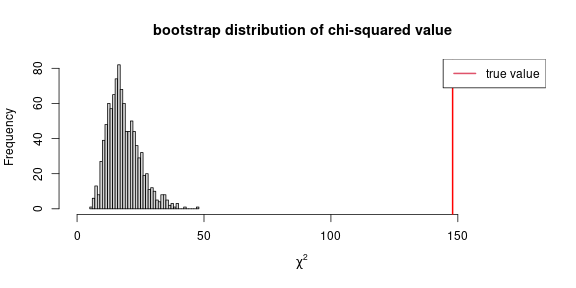

## Conclusion?

(What did we actually test?)

## Your turn:

Use a permutation test to assess whether the relation between hair and eye color differs by sex.

To do this, we’ll:

1. Compute the sum of squared differences between each of the 16 proportions (4 eye x 4 hair colors). *(test statistic)*
2. Compute the same thing, after shuffling up the `sex` column, a bunch of times.
3. Compare the observed value to the distribution under permutations from (2).

## Compute the test statistic

```r
female_freqs <- with(subset(long_haireye, sex=="Female"), table(eye, hair)) / sum(long_haireye$sex == "Female")
male_freqs <- with(subset(long_haireye, sex=="Male"), table(eye, hair)) / sum(long_haireye$sex == "Male")
ssd <- sum( (female_freqs - male_freqs)^2 )
```

## Do the same thing after permuting `sex`

```r
nperms <- 1000
perm_ssd <- rep(NA, nperms)
for (j in 1:nperms) {
    sex_shuffled <- sample(long_haireye$sex)
    female_freqs <- with(subset(long_haireye, sex_shuffled=="Female"), table(eye, hair)) / sum(long_haireye$sex == "Female")
    male_freqs <- with(subset(long_haireye, sex_shuffled=="Male"), table(eye, hair)) / sum(long_haireye$sex == "Male")
    perm_ssd[j] <- sum( (female_freqs - male_freqs)^2 )
}
```

## Compare

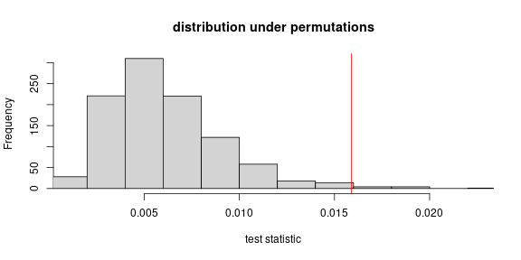

```r
hist(perm_ssd, xlim=range(perm_ssd, ssd), xlab='test statistic', main='distribution under permutations')
abline(v=ssd, col='red')
```